# iris

## Apprentissage Automatique Numerique

L’objectif de ce mini-projet est de programmer un classifieur bayesien. L’exemple choisi est la classifica- tion de tres beau specimens d’iris (la fleur). Chaque iris est represent´ee par 4 parametres caract´eristiques : la largeur et la longueur de leur p´etale et de leur s´epale. Chaque iris est donc code par un vecteur de r´eels de dimension 4.

Le travail demande consiste en deux phases :

- Apprentissage des parametres du classifieur bayesien avec les donnees d’apprentissage
- Determination des parametres optimaux du classifieur avec les donnees de developpement
- L’utilisation du classifieur pour tester ces performances sur les donnees de test

Les instructions Python suivantes permettent de charger le jeu de donnees Iris, et d’afficher la partie data (description des donnees en termes d’attributs) et la partie target (classe, cible, etiquette)

### data set : https://fr.wikipedia.org/wiki/Iris_de_Fisher

```python
from sklearn import datasets
import numpy as np
import matplotlib.pyplot as plt
import matplotlib.mlab as mlab


%matplotlib inline
```

```python
iris = datasets.load_iris()
print(iris.data[:4])
print(iris.target)
```

```
[[ 5.1  3.5  1.4  0.2]
 [ 4.9  3.   1.4  0.2]
 [ 4.7  3.2  1.3  0.2]
 [ 4.6  3.1  1.5  0.2]]
[0 0 0 0 0 0 0 0 0 0 0 0 0 0 0 0 0 0 0 0 0 0 0 0 0 0 0 0 0 0 0 0 0 0 0 0 0
 0 0 0 0 0 0 0 0 0 0 0 0 0 1 1 1 1 1 1 1 1 1 1 1 1 1 1 1 1 1 1 1 1 1 1 1 1
 1 1 1 1 1 1 1 1 1 1 1 1 1 1 1 1 1 1 1 1 1 1 1 1 1 1 2 2 2 2 2 2 2 2 2 2 2
 2 2 2 2 2 2 2 2 2 2 2 2 2 2 2 2 2 2 2 2 2 2 2 2 2 2 2 2 2 2 2 2 2 2 2 2 2
 2 2]
```

### 1. Division de l’´echantillon d’apprentissage

```python
Ciris = np.c_[iris.data.reshape(len(iris.data), -1), iris.target.reshape(len(iris.target), -1)]
np.random.seed(987654321)

print(Ciris[:4])

np.random.shuffle(Ciris)
shuffledIrisData = Ciris[ :, :iris.data.size//len(iris.data)].reshape(iris.data.shape)
shuffledIrisTarget = Ciris[ :, iris.data.size//len(iris.data) :].reshape(iris.target.shape)
```

```
[[ 5.1  3.5  1.4  0.2  0. ]
 [ 4.9  3.   1.4  0.2  0. ]
 [ 4.7  3.2  1.3  0.2  0. ]
 [ 4.6  3.1  1.5  0.2  0. ]]
```

```python
learn = shuffledIrisData[0:100]
dev = shuffledIrisData[101:130]
test = shuffledIrisData[131:]

learn_target = shuffledIrisTarget[0:100]
dev_target = shuffledIrisTarget[101:130]
test_target = shuffledIrisTarget[131:]
```

### 2. Phase d’apprentissage

Il faut estimer deux types de probabilites :

- Les probabilites a priori p(ωi) pour i = {0, 1, 2}
- Les vraisemblances (probabilites conditionnelles) P(x|ωi). On suppose que celles-ci suivent une loi Gaussienne de dimension 2. Il s’agit donc d’obtenir la moyenne µi (vecteur de dimension 2) et la matrice de variance-covariance Σi (matrice de dimension 2 × 2), separement pour chaque classe ωi .

```python
class GaussianNB(object):
    all_color =  ['b', 'g', 'r', 'c', 'm', 'y', 'k', 'w']

    def __init__(self, feature_names, target_names, select_features):
        """
        feature_names is Array( "name of feature 0", "name of feature 1", ..)
        target_names is Array ( "name of class0", ..)
        """
        self.feature_names = np.array(feature_names)[select_features]
        self.target_names = target_names
        self._init_color()

    def _init_color(self):
        self.color = self.all_color[:len(self.target_names)]

    def fit(self, X, y, select_features):
        separated = self._extract_feature_class(X[:, select_features],y)
#         print(separated[0])
#         print(np.mean(separated[0], axis=0))
        self.model = self._calcul_model(separated)
#         print(self.model)
        self.wi_mean = self.calculate_wi_mean(y)
        return self

    def calculate_wi_mean(self, y):
        """Les probabilités a priori"""
        return np.array( [ list(y).count(class_x)/len(y) for class_x in np.unique(y)] )



    def _extract_feature_class(self, X, y):
        """
        extract features by class association
        return  Array(
                    Array(feature_1, feature_2,..) /* for class 0 */,
                    Array(feature_1, feature_2,..) /* for class 1 */,
                    ..)
        """
        result = []
        for class_x in np.unique(y):
            separated = []
            for features, target in zip(X, y):
                if target == class_x:
                    separated.append(features)
            result.append(separated)
        return result


    def _calcul_model(self, separated):
        """
        caclulate the mean and the standard deviation of each feature for each class.
        return Array(
                    Array(mean, std) /* for class 0 */,
                    Array(mean, std) /* for class 1 */,
                    ..)
        """
        return np.array([np.c_[np.mean(i, axis=0), np.std(i, axis=0)] # np.c_ == zip
            for i in separated])


    def _make_plot(self, mu, std):
        sigma = std
        x = np.linspace(mu - 3*sigma, mu + 3*sigma, 100)
        label = "μ = %.02f σ = %.02f" % (mu, sigma)
        plt.plot(x,mlab.normpdf(x, mu, sigma), self.color.pop(), label = label)


    def plot_features(self):
        """
        display x plot (x == num of features) each plot has y fig ( y == num of classes)
        """
        tmp_feature_name = list(self.feature_names) # copy the list
        transpose = self.model.transpose()

        # Array ( Array(class1, class2, ...) --> feature1, ... )
        mu = transpose[0]
        stds = transpose[1]

        for m,s in zip(mu, stds):
            plt.title(tmp_feature_name.pop(0), y=1.10)
            plt.xlabel('x')
            plt.ylabel('P(μ, σ)(x)')
            for a, b in zip(m,s):
                self._make_plot(a,b)
            self._init_color()

            first_legend = plt.legend()
            ax = plt.gca().add_artist(first_legend)
            # Create another legend for the second line.
            plt.legend(self.target_names, bbox_to_anchor=(0,1.02,1,0.2), loc="lower right",
                mode="expand", borderaxespad=0, ncol=len(self.target_names))

            plt.show()


    def _norm_pdf(self, x, mean, std):
        """
        Gaussian distribution
        http://en.wikipedia.org/wiki/Normal_distribution#Probability_density_function
        """
        var = std**2
        denom = np.sqrt(2*np.pi*var)
        num = np.exp(-(float(x)-float(mean))**2/(2*var))
        return num/denom


    def predict_proba(self, X):
        return np.array([ self.wi_mean * [sum(self._norm_pdf(i, *m) for m, i in zip(model, x))
                for model in self.model] for x in X])

    def predict(self, X):
        return np.argmax(self.predict_proba(X), axis=1)

    def score(self, X, y):
        return sum(self.predict(X) == y) / len(y)

    def plot_for_2_feature(self, X, Y, feature_index = [0,1]):
        """
        plot only 2 dim (2 features)
        by default it will be the first(0) and second(1) features
        """
        # Plot
        fig = plt.figure(figsize=(5, 3.75))
        ax = fig.add_subplot(111)
        for x, y, class_x, class_res in zip(X[:, feature_index[0]], X[:, feature_index[1]], self.predict(X), Y):

            # target class
            ax.scatter(x,y,100, color=self.all_color[class_res.astype(int)],
                        edgecolor='k')

            # predict class
            ax.scatter(x,y,20, color=self.all_color[class_x],
                        edgecolor='k')


        # Plot formatting
        plt.title("Confusion Plot (IN = predict, LAYER = real)")
        ax.set_xlabel(self.feature_names[feature_index[0]])
        ax.set_ylabel(self.feature_names[feature_index[1]])

        plt.tight_layout()
        plt.show()

# print(nb.predict_proba(dev[:5]))

# print("Model:")
# print(nb.model)

# print("\nPredict_proba")
# print(nb.predict_proba(dev[:5]))

# print("\nFeatures values dev:")
# print(dev_target[:5])
# print("\nPredict values dev:")
# print(nb.predict(dev[:5]))
```

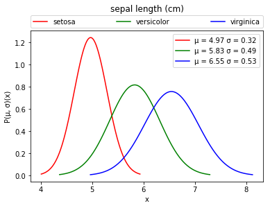

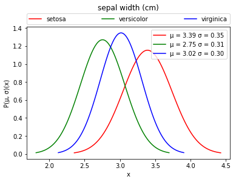

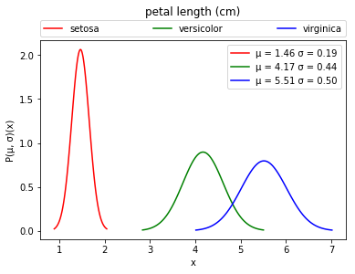

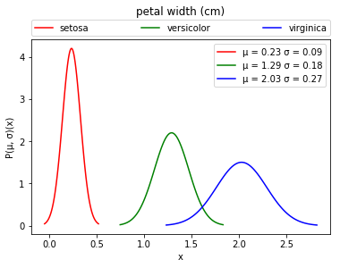

```python
feature_selected = [0,1,2,3]

feature_selected_name = np.array(iris.feature_names)[feature_selected]

nb = GaussianNB(iris.feature_names, iris.target_names, feature_selected)
nb.fit(learn, learn_target, feature_selected)
nb.plot_features()
```

On note que individuellement, les features **petal width** et **petal lenght** semble être les features les plus discriminant.  
Un expert diras surement qu'elle sont trop corréler ?

```
Learn with ['sepal length (cm)' 'sepal width (cm)'] comb: [0 1]
Score Learn: 0.71
```

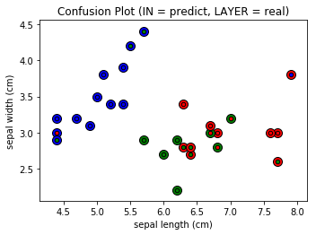

```
Score dev: 0.586206896552

Learn with ['sepal length (cm)' 'petal length (cm)'] comb: [0 2]
Score Learn: 0.87
```

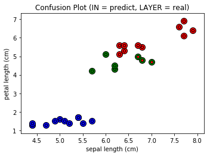

```
Score dev: 0.896551724138

Learn with ['sepal length (cm)' 'petal width (cm)'] comb: [0 3]
Score Learn: 0.96
```

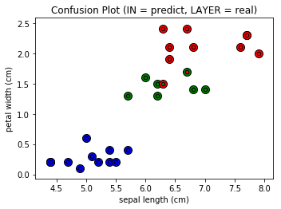

```
Score dev: 0.931034482759

Learn with ['sepal width (cm)' 'petal length (cm)'] comb: [1 2]
Score Learn: 0.85
```

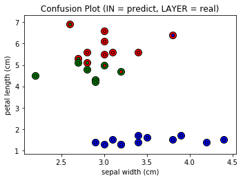

```
Score dev: 0.793103448276

Learn with ['sepal width (cm)' 'petal width (cm)'] comb: [1 3]
Score Learn: 0.96
```

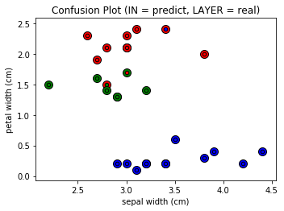

```
Score dev: 0.896551724138

Learn with ['petal length (cm)' 'petal width (cm)'] comb: [2 3]
Score Learn: 0.99
```

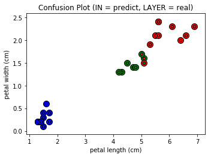

```
Score dev: 0.896551724138

Learn with ['sepal length (cm)' 'sepal width (cm)' 'petal length (cm)'] comb: [0 1 2]
Score Learn: 0.81
```

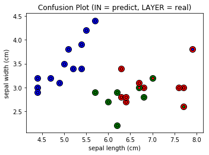

```
Score dev: 0.862068965517

Learn with ['sepal length (cm)' 'sepal width (cm)' 'petal width (cm)'] comb: [0 1 3]
Score Learn: 0.93
```

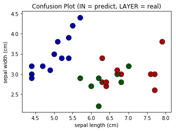

```
Score dev: 0.931034482759

Learn with ['sepal length (cm)' 'petal length (cm)' 'petal width (cm)'] comb: [0 2 3]
Score Learn: 0.97
```

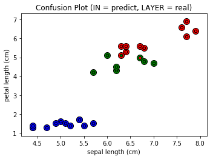

```
Score dev: 0.931034482759

Learn with ['sepal width (cm)' 'petal length (cm)' 'petal width (cm)'] comb: [1 2 3]
Score Learn: 0.97
```

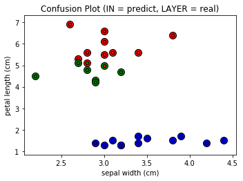

```
Score dev: 0.931034482759

Learn with ['sepal length (cm)' 'sepal width (cm)' 'petal length (cm)'
 'petal width (cm)'] comb: [0 1 2 3]
Score Learn: 0.98
```

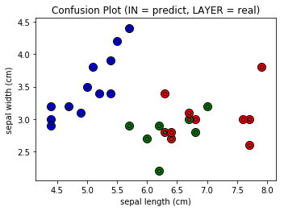

```
Score dev: 0.931034482759

Best of the best
0.0 ['sepal length (cm)' 'sepal width (cm)' 'petal length (cm)'
 'petal width (cm)']
```

```python
def combs(x):
    import itertools
    return [np.array(c) for i in range(len(x)+1) for c in itertools.combinations(x,i)]

combi_best = 0.0
features_best = []

for comb in combs(range(len(iris.feature_names))):

    if len(comb) >= 2:
        # Choose the feature here
        feature_selected = comb

        feature_selected_name = np.array(iris.feature_names)[feature_selected]

        nb = GaussianNB(iris.feature_names, iris.target_names, feature_selected)
        nb.fit(learn, learn_target, feature_selected)

        score = nb.score(dev[:, feature_selected],dev_target)
        if (score > combi_best):
            features_best = feature_selected_name

        print("\nLearn with", feature_selected_name, "comb:", comb)
        print("Score Learn:", nb.score(learn[:, feature_selected], learn_target))

        nb.plot_for_2_feature(dev[:, feature_selected], dev_target)
        print("Score dev:", nb.score(dev[:, feature_selected], dev_target))

print("\nBest of the best")
print(combi_best, features_best)
```

On remarque que sur le corpus de dev la meilleur notes est 0.931034482759

sur les entraînements de

```
* 'sepal length (cm)' 'petal width (cm)'
* 'sepal length (cm)' 'sepal width (cm)' 'petal width (cm)'
* 'sepal length (cm)' 'petal length (cm)' 'petal width (cm)'
* 'sepal width (cm)' 'petal length (cm)' 'petal width (cm)'
* 'sepal length (cm)' 'sepal width (cm)' 'petal length (cm)' 'petal width (cm)'
```

Comme quoi les features '**sepal length (cm)**' '**petal width (cm)**' *(indice [0,3])* sont apparemment celle qui **discriminent** le plus nos iris

```
Matrice de confusion DEV :
[[ 12.   0.   0.]
 [  0.   6.   1.]
 [  0.   1.   9.]]
Matrice de confusion TEST :
[[ 6.  0.  1.]
 [ 0.  5.  1.]
 [ 0.  1.  5.]]
```

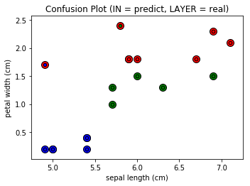

```
Score test: 0.842105263158
```

```python
def matriceConfusion(estimation, target):
    matrice = np.zeros((3, 3))

    for i in range(len(estimation)):
        matrice[estimation[i]][int(target[i])] += 1

    return matrice

feature_selected = [0,3]

nb = GaussianNB(iris.feature_names, iris.target_names, feature_selected)
nb.fit(learn, learn_target, feature_selected)

print("Matrice de confusion DEV :")
print(matriceConfusion(nb.predict(dev[:, feature_selected]), dev_target))
print("Matrice de confusion TEST :")
print(matriceConfusion(nb.predict(test[:, feature_selected]), test_target))

corpus = test[:, feature_selected]
target = test_target

nb.plot_for_2_feature(corpus, target)

print("Score test:", nb.score(corpus, target))
```

```python
from sklearn.naive_bayes import GaussianNB as GaussianNB_sklearn

clf = GaussianNB_sklearn()
clf.fit(learn, learn_target)
print("SKLEAN naive bayes")
print("Score test:",clf.score(test, test_target))
```

```
SKLEAN naive bayes
Score test: 0.842105263158
```